# Report 2. Impact of the features in the model and conclusions

In this report will be commented the features our model has selected and the consecuences of them using the shap tool

1. Features
2. Conclusions

```python
import sys, os; sys.path.insert(0, os.path.dirname(os.getcwd()))
import pandas as pd
import utils.io
import utils.preprocessing
import numpy as np
import matplotlib.pyplot as plt
import sklearn.linear_model
import xgboost
import shap
import warnings
from sklearn.model_selection import train_test_split
from sklearn.ensemble import GradientBoostingRegressor
from mlxtend.feature_selection import SequentialFeatureSelector

# Environment settings:
from IPython.core.interactiveshell import InteractiveShell
InteractiveShell.ast_node_interactivity = "all"
pd.set_option('display.max_column', None)
```

Retrieve the data

```python
data = utils.io.retrieve_processed_dataset()
data = data.select_dtypes(include='number').dropna()
```

Using the model as in report 1

```python
y = data['target']
X = data.drop(columns='target')

X_train, X_test, y_train, y_test = train_test_split(X, y, test_size=0.3, random_state=42)

model = xgboost.XGBRegressor()
model.fit(X_train, y_train)
```

```
XGBRegressor(base_score=0.5, booster='gbtree', colsample_bylevel=1,
             colsample_bynode=1, colsample_bytree=1, gamma=0, gpu_id=-1,
             importance_type='gain', interaction_constraints='',
             learning_rate=0.300000012, max_delta_step=0, max_depth=6,
             min_child_weight=1, missing=nan, monotone_constraints='()',
             n_estimators=100, n_jobs=4, num_parallel_tree=1, random_state=0,
             reg_alpha=0, reg_lambda=1, scale_pos_weight=1, subsample=1,
             tree_method='exact', validate_parameters=1, verbosity=None)
```

##### Features analysis

By the `SHAP` (SHapley Additive exPlanations) tool we analyse the more relevant features in the model

```python
shap.initjs()
```

```python
explainer = shap.TreeExplainer(model)
shap_values = explainer.shap_values(X_train)
```

Analysis of the features and their importance

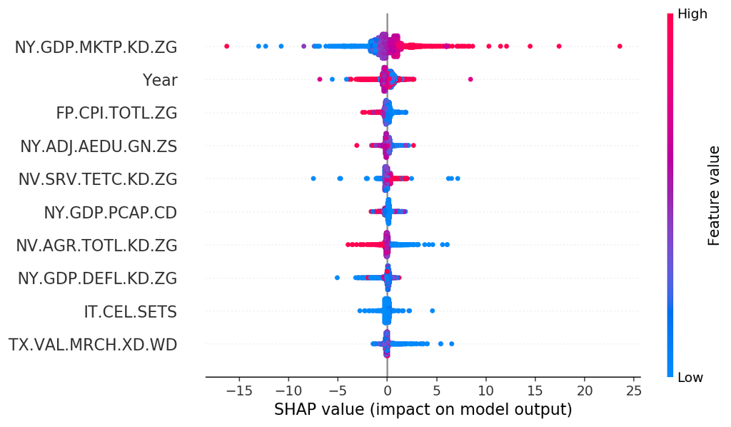

```python
shap.summary_plot(shap_values, X_train, max_display= 10)
```

We see by this plot the impact of 10 more relevant features in our model, being:.

- **NY.GDP.MKTP.KD.ZG** $\;$ -------> $\;$**GDP growth (annual %)**
- Year $\;\;\;\;\;\;\;\;\;\;\;\;\;\;\;\;$$\;\;\;\;\;\;$ -------> $\;$Year
- FP.CPI.TOTL.ZG $\;\;\;\;\;\;\;$ -------> $\;$Inflation, consumer prices (annual %)
- NY.ADJ.AEDU.GN.ZS $\;\;$-------> $\;$Adjusted savings: education expenditure (% of GNI)
- NV.SRV.TETC.KD.ZG $\;\;\;$-------> $\;$Services, etc., value added (annual % growth)
- NY.GDP.PCAP.CD $\;\;\;\;\;\;$ ------->$\;$ GDP per capita (current US dollars)
- NV.AGR.TOTL.KD.ZG $\;\;$-------> $\;$Agriculture, forestry, and fishing, value added (annual % growth)
- NY.GDP.DEFL.KD.ZG $\;\;$-------> $\;$Inflation, GDP deflator (annual %)
- IT.CEL.SETS $\;\;\;\;\;\;$ $\;\;\;\;\;\;$-------> $\;$Mobile cellular subscriptions
- TX.VAL.MRCH.XD.WD $\;$-------> $\;$Export value index

Some features are obvious to be in this list, like GDP per capita or Inflation but other like number of Mobile cellular subscriptions may be not so obvious. However this list of more relevant features seems to make sense as we are predicting GDP growth.

In this plot we see the average impact of most relevant features on our model output.  
Of course the `GDP growth` is the most important but the year seem to be important too.

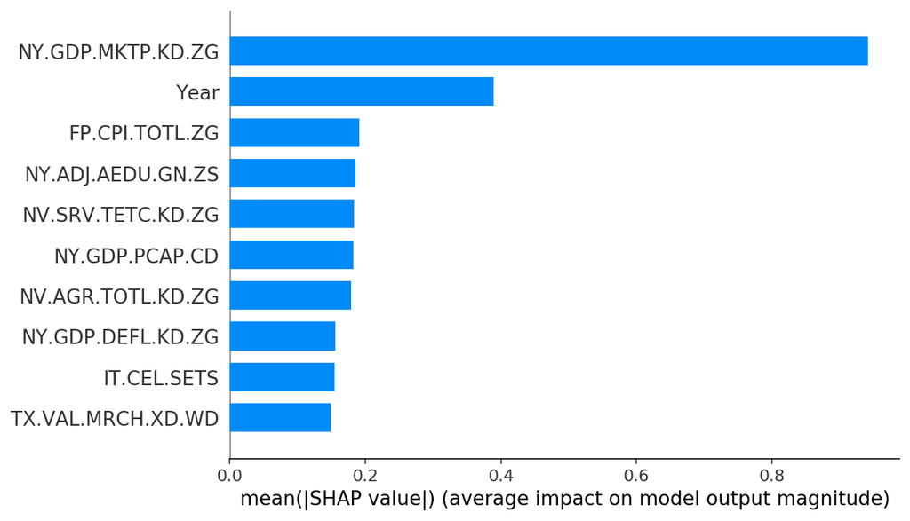

```python
shap.summary_plot(shap_values, X_test, plot_type="bar", max_display=10)
```

Analysis by year. More recient years seem to have more relevance in the `GDP growth` rate.

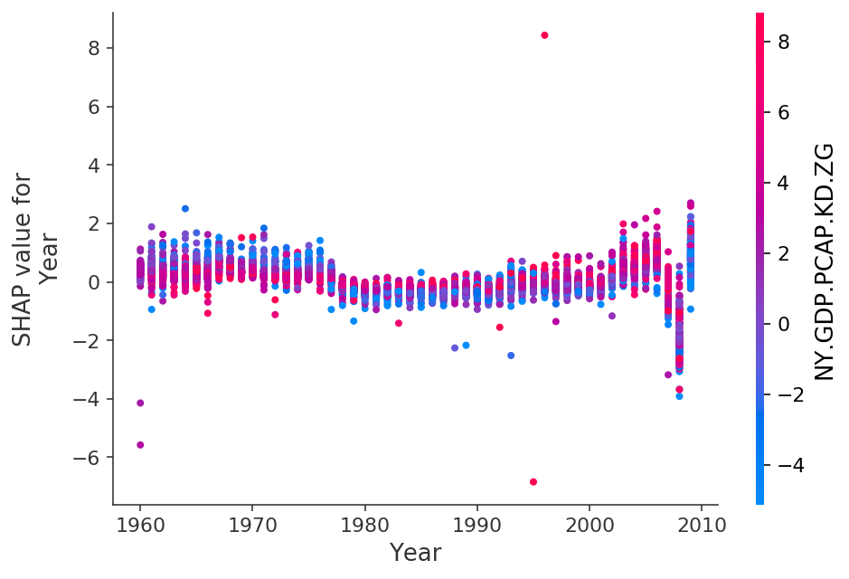

```python
shap.dependence_plot("Year", shap_values, X_train)
```

By the heatmap we display above is shown the model inputs with the instances and the `SHAP` values. Again we see the importance of each feature, ordered by relevance.

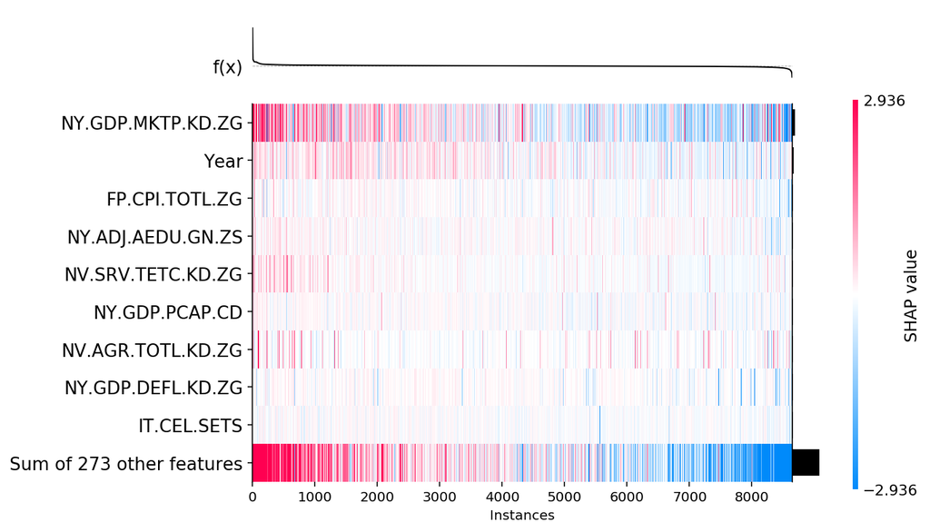

```python
shap.plots.heatmap(shap_values, max_display= 10,instance_order=shap_values.sum(1))
```

Finally we will take a look at an other plot

```python
expected_value = explainer.expected_value
print(f"Explainer expected value: {expected_value}")

select = range(10)
features = X_test.iloc[select]
features_display = X.loc[features.index]

with warnings.catch_warnings():
    warnings.simplefilter("ignore")
    shap_values = explainer.shap_values(features)[1]
    shap_interaction_values = explainer.shap_interaction_values(features)
if isinstance(shap_interaction_values, list):
    shap_interaction_values = shap_interaction_values[1]
```

```
Explainer expected value: 4.204092025756836
```

This plot above displays the ordered features importance over the predicted `GDP growth`. At the top of the plot is shown the predicted value and the effect on how each feature contribute to the predicted expected value. We can see how at the end it will converge to the expected value although we only show the 180 morerelevant features.

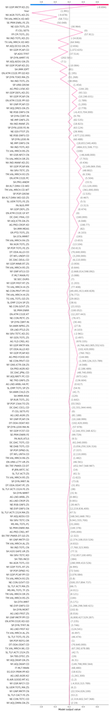

```python
shap.decision_plot(expected_value, shap_values, features_display, feature_display_range=slice(-1, -181, -1),ignore_warnings=True)
```

#### Conclusions

So we can conclude that although we have a huge number - 282 exactly - of features not all of them have the same relevance when we are training and testing a model with `Extreme Gradient Boosting`. However, this more relevant features are the one as we expected to be, all of them related with economic and social characteristics. Also, some dimensional features as the `Year` one seem to have a different relevance in the GDP growth, a thing that we expected to happen as well.